# ggplot2 Elegant Graphics for Data Analysis

# 4 Non-linear Coordinate Systems

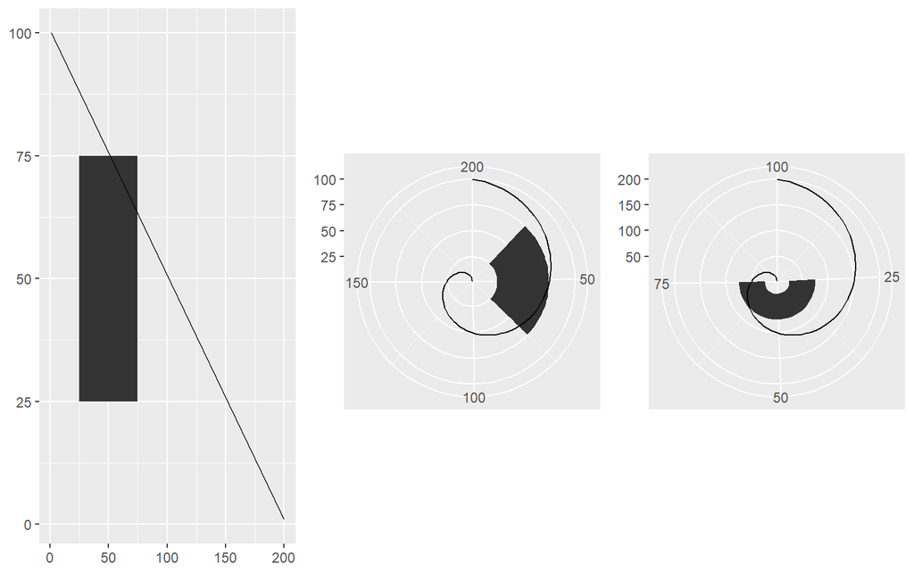

```r
rect <- data.frame(x = 50, y = 50)
line <- data.frame(x = c(1, 200), y = c(100, 1))
base <- ggplot(mapping = aes(x, y)) +
  geom_tile(data = rect, aes(width = 50, height = 50)) +
  geom_line(data = line) +
  xlab(NULL) + ylab(NULL)
grid.arrange(
base,
base + coord_polar("x"),
base + coord_polar("y"), ncol = 3)
```

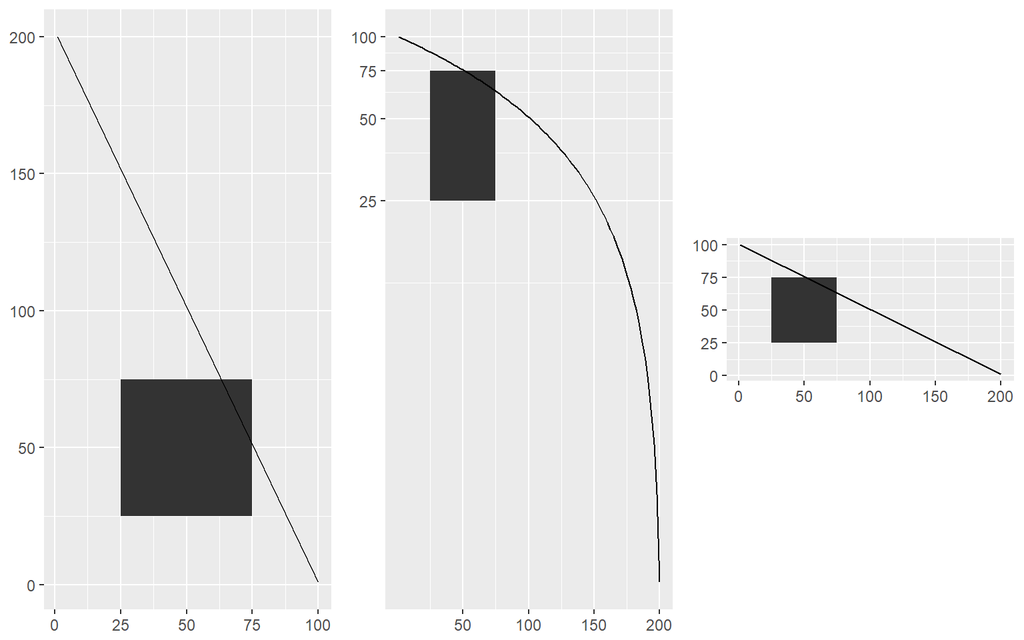

```r
grid.arrange(
base + coord_flip(),
base + coord_trans(y = "log10"),
base + coord_fixed(), ncol = 3)
```

1. We start with a line parameterised by its two endpoints:

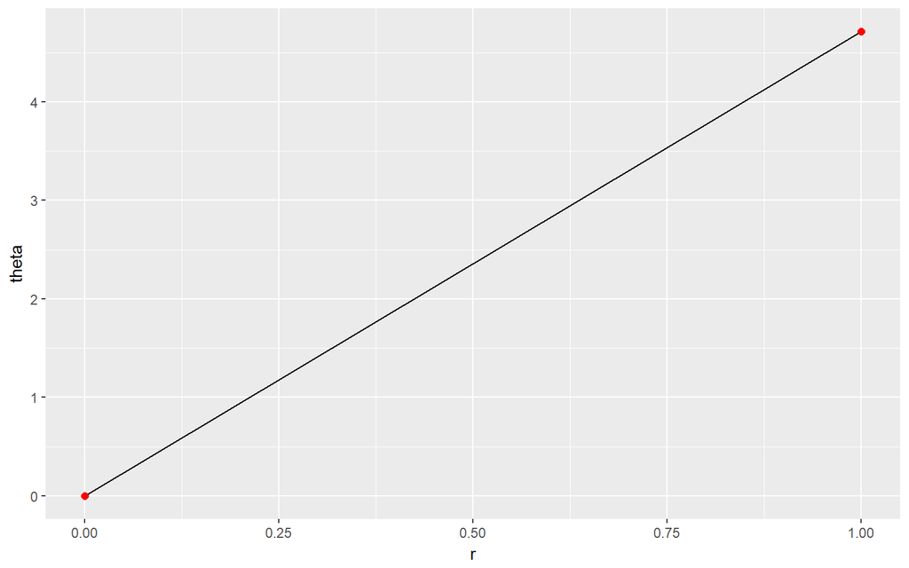

```r
df <- data.frame(r = c(0, 1), theta = c(0, 3 / 2 * pi))
ggplot(df, aes(r, theta)) +
  geom_line() +
  geom_point(size = 2, colour = "red")
```

2. We break it into multiple line segments, each with two endpoints.

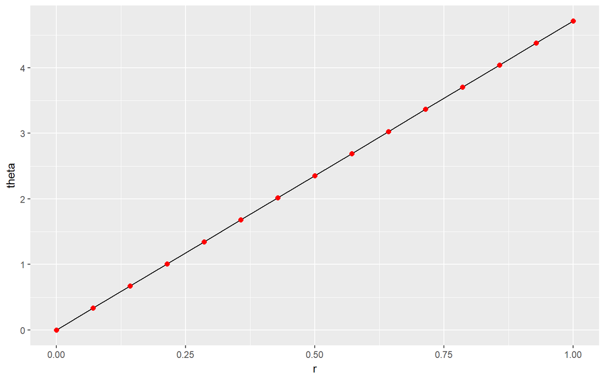

```r
interp <- function(rng, n) {
  seq(rng[1], rng[2], length = n)
}
munched <- data.frame(
  r = interp(df$r, 15),
  theta = interp(df$theta, 15)
)
ggplot(munched, aes(r, theta)) +
  geom_line() +
  geom_point(size = 2, colour = "red")
```

3. We transform the locations of each piece:

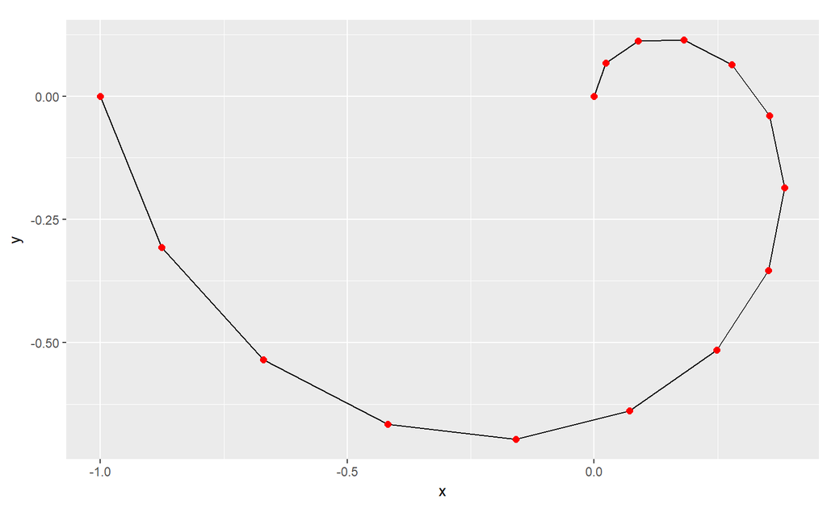

```r
transformed <- transform(munched,
                         x = r * sin(theta),
                         y = r * cos(theta)
)
ggplot(transformed, aes(x, y)) +
  geom_path() +
  geom_point(size = 2, colour = "red") +
  coord_fixed()
```

## 4.1 Transformations with **coord_trans()**

scale level에서의 변환은 기하객체의 모양을 변화시키지 않지만 coordinate system level에서의 변환은 통계량 계산 후, 변환되고 기하객체의 모양에 영향을 끼친다. 변환된 스케일의 데이터를 모델링하고 이것을 해석을 위해 역변환 시키는 방법을 사용하라. 분석의 흔한 패턴이다

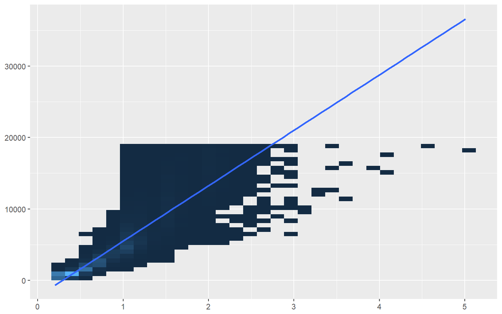

```r
# Linear model on original scale is poor fit
base <- ggplot(diamonds, aes(carat, price)) +
  stat_bin2d() +
  geom_smooth(method = "lm") +
  labs(x = NULL, y = NULL) +
  theme(legend.position = "none")
base
```

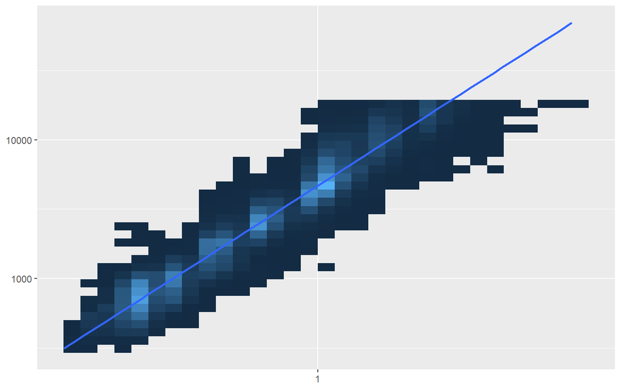

```r
# Better fit on log scale, but harder to interpret
base +
  scale_x_log10() +
  scale_y_log10()
```

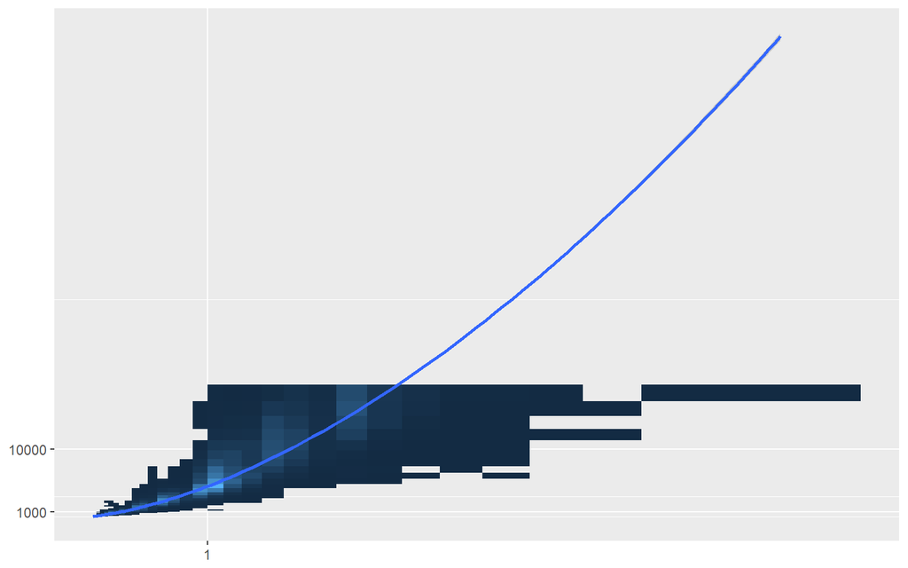

```r
# Fit on log scale, then backtransformation to original
# Highlights lack of expensive diamonds with large carats
pow10 <- scales::exp_trans(10)
base +
  scale_x_log10() +
  scale_y_log10() +
  coord_trans(x = pow10, y = pow10)
```

세번째 플랏에서 회귀직선과 bin의 색이 첫번째 플랏과 다른 이유는 통게량 계산 후 좌표변환이 이루어 지기 때문이다!

## 4.2 Polar Coordiantes with **coord_polar()**

pie charts, wind roses, rader chart에서 사용한다. 극좌표는 시간이나 방향에 종종 이용되지만 지각적으로 좋지않다.

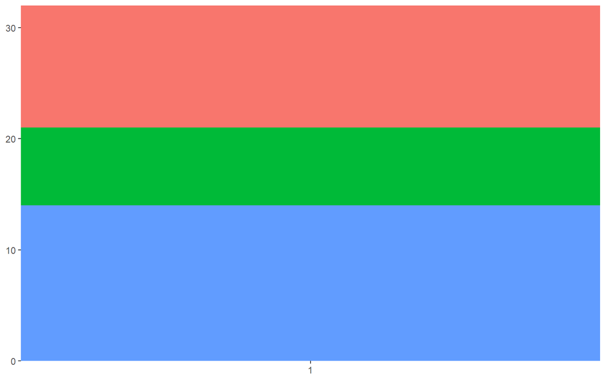

```r
base <- ggplot(mtcars, aes(factor(1), fill = factor(cyl))) +
  geom_bar(width = 1) +
  theme(legend.position = "none") +
  scale_x_discrete(NULL, expand = c(0, 0)) +
  scale_y_continuous(NULL, expand = c(0, 0))

# Stacked barchart
base
```

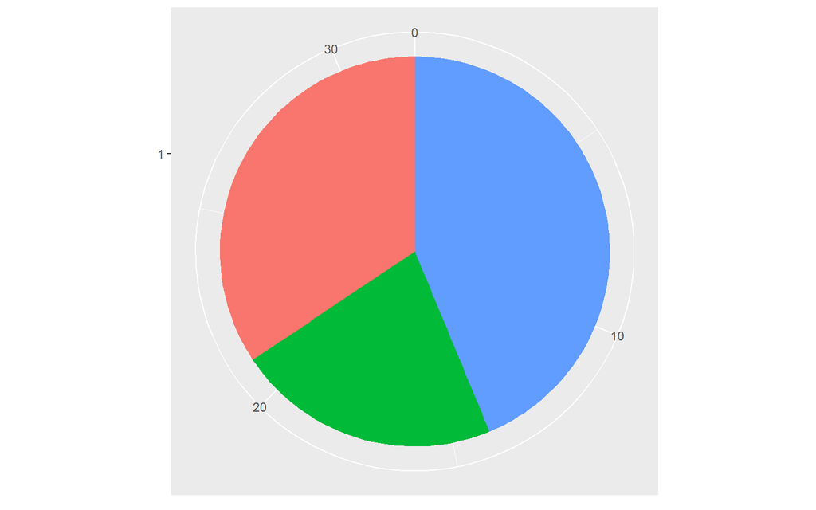

```r
# Pie chart
base + coord_polar(theta = "y")
```

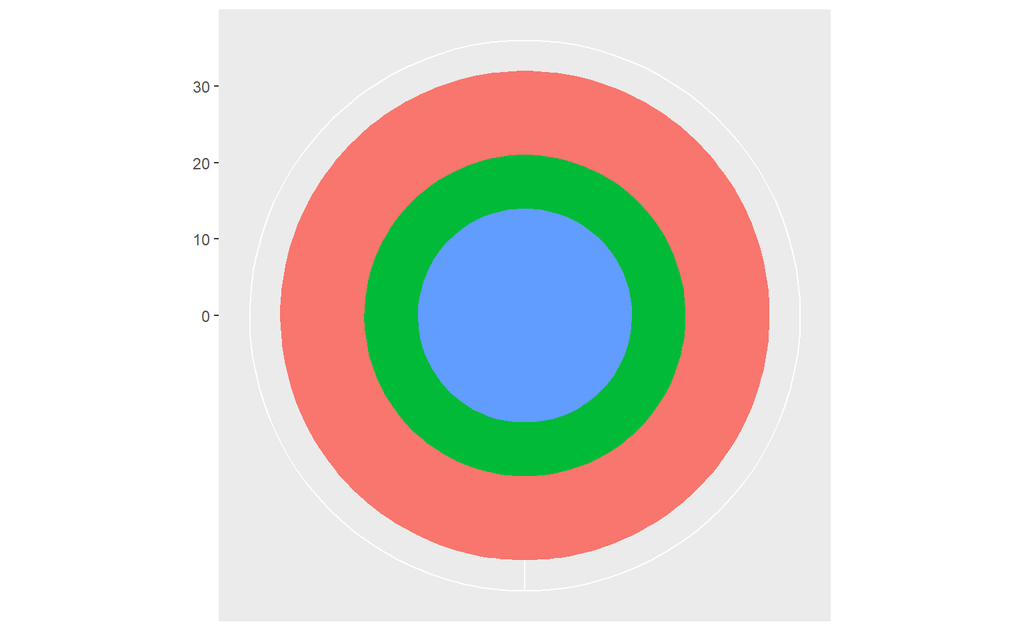

```r
# The bullseye chart
base + coord_polar()
```

## 4.3 Map Projections with **coord_map()**

- `coord_quickmap()`은 1m경도와 1m위도가 플랏에서 거리가 동일하다. 작은 지역에서 합리적이고 매우 빠르다.

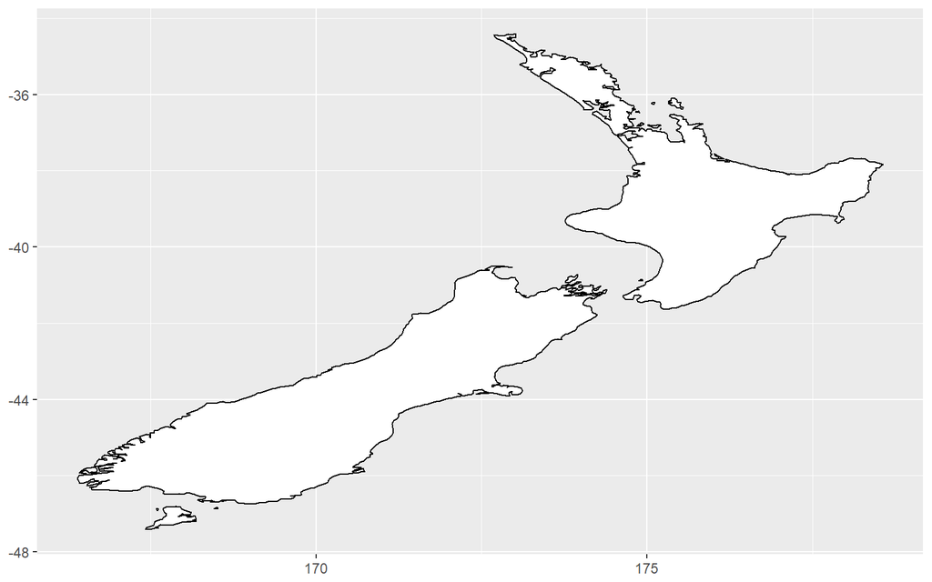

```r
nzmap <- ggplot(map_data("nz"), aes(long, lat, group = group)) +
  geom_polygon(fill = "white", colour = "black") +
  xlab(NULL) + ylab(NULL)
# Plot it in cartesian coordinates
nzmap
```

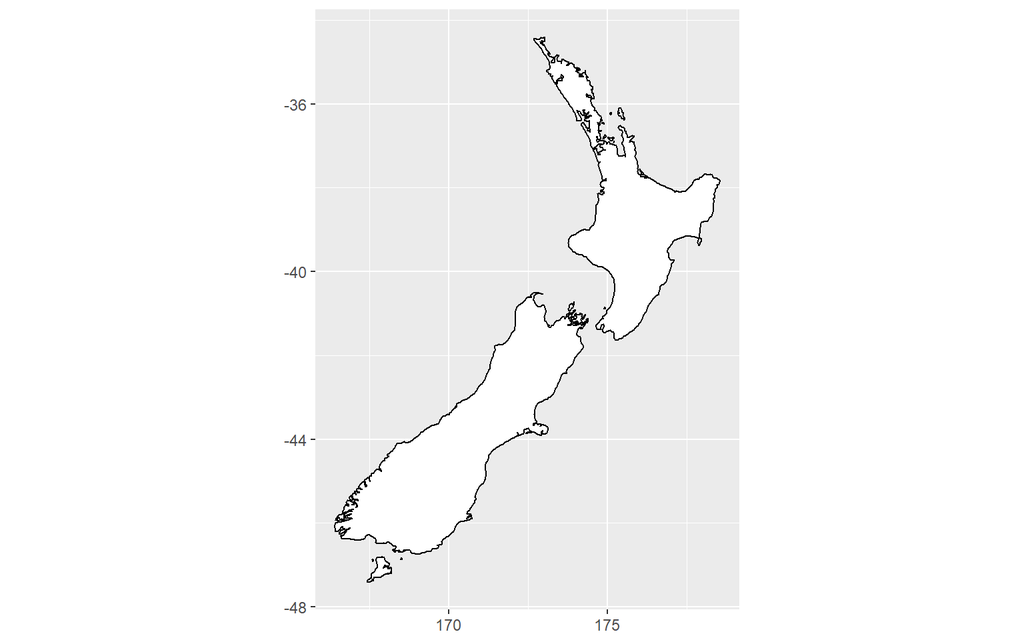

```r
# With the aspect ratio approximation
nzmap + coord_quickmap()
```

- `coord_map()`은 mapproj 패키지를 사용한다.

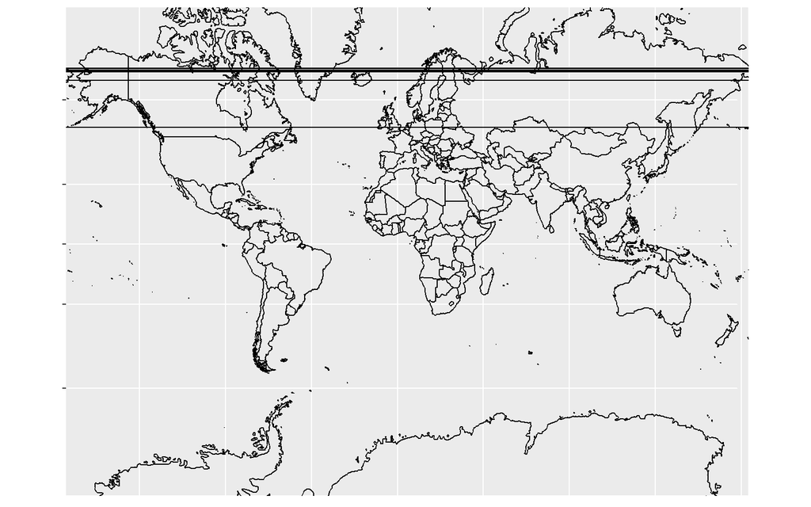

```r
world <- map_data("world")
worldmap <- ggplot(world, aes(long, lat, group = group)) +
  geom_path() +
  scale_y_continuous(NULL, breaks = (-2:3) * 30, labels = NULL) +
  scale_x_continuous(NULL, breaks = (-4:4) * 45, labels = NULL)

worldmap + coord_map()
```

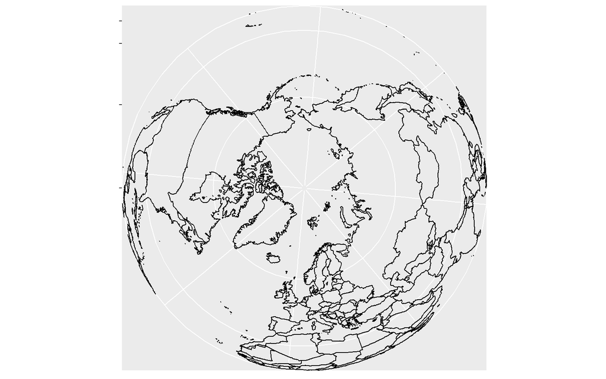

```r
# Some crazier projections
worldmap + coord_map("ortho")
```

[figure not shown]

```r
worldmap + coord_map("stereographic")
```

# 5 Summary

- `facet_grid()` 에 있는 `space` 인자를 활용하여 범주형 변수를 표현하자. 두 개의 이상형 변수를 표현할 때 유용.
- `scales = "free_y", ncol = 1`은 다른 스케일로 측정된 다수의 시계열을 나타낼 때 유용하다.
- 각 패널의 배경에 모든 데이터를 그려놓고 grouping하면 유용하다.
- 연속형 변수를 이산화하기 : `cut_interval(x, n)` `cut_width(x, width)` `cut_number(x, n)`
- 적절한 경우에 `coord_cartesian(xlim = c( , ))` 또는 `scale_x_continuous(limits = c( , ))`를 사용하자.
- 변환된 스케일의 데이터를 모델링하고 이것의 해석을 위해 역변환 시키자. `pow10 = scales::exp_trans(10)` `coord_trans(x = pow10, y = pow10)`